# Exercise10

Matt Ming

4/9/2022

# Coding Challenge

Load in necessary packages

```r
library(readr)
library(ggplot2)
library(dplyr)
```

Load in the Kamilar and Cooper 2013 dataset

```r
f <- "https://raw.githubusercontent.com/difiore/ada-2022-datasets/main/KamilarAndCooperData.csv"
d <- read_csv(f)
```

Plot lifespan (MaxLongevity_m) versus female body mass (Body_mass_female_mean). Is the relationship linear? Can we transform the data?

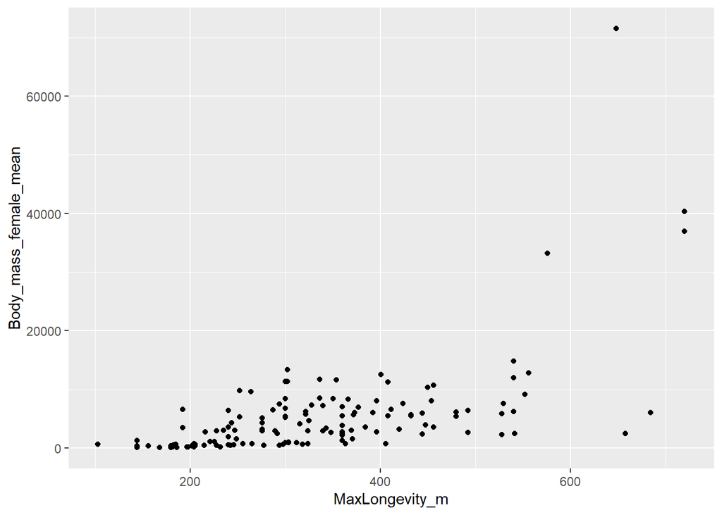

```r
p <- d %>% select(MaxLongevity_m,Body_mass_female_mean) %>%
  na.omit() %>% ggplot(aes(MaxLongevity_m,Body_mass_female_mean))
p <- p + geom_point()
print(p)
```

From visual inspection, it does not appear that this relationship is linear, as we see many points with low female body mass but there are a couple points with high longevity which also have high female body mass. It seems like this data could be transformed using a log scale, but from pure visual inspection it is difficult to tell which axis (or both) should be transformed.

Run linear models of lifespan ~ F body mass, lifespan ~ log(F body mass), and log(lifespan) ~ log(F body mass)

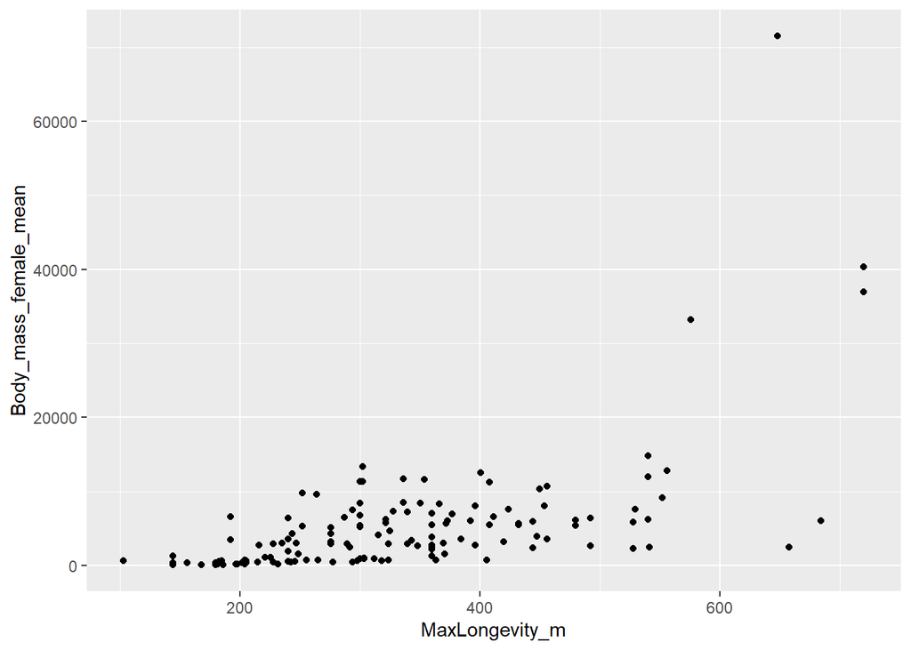

```r
d2 <- d %>% select(MaxLongevity_m,Body_mass_female_mean) %>% na.omit() %>%
  mutate(LogLongevity = log(MaxLongevity_m),
         LogFemBM = log(Body_mass_female_mean))

p1 <- ggplot(d2,aes(MaxLongevity_m,Body_mass_female_mean)) + geom_point()
p2 <- ggplot(d2,aes(MaxLongevity_m,LogFemBM)) + geom_point()
p3 <- ggplot(d2,aes(LogLongevity,LogFemBM)) + geom_point()

print(p1)
```

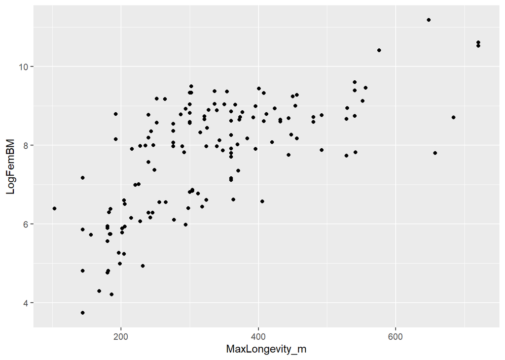

```r
print(p2)
```

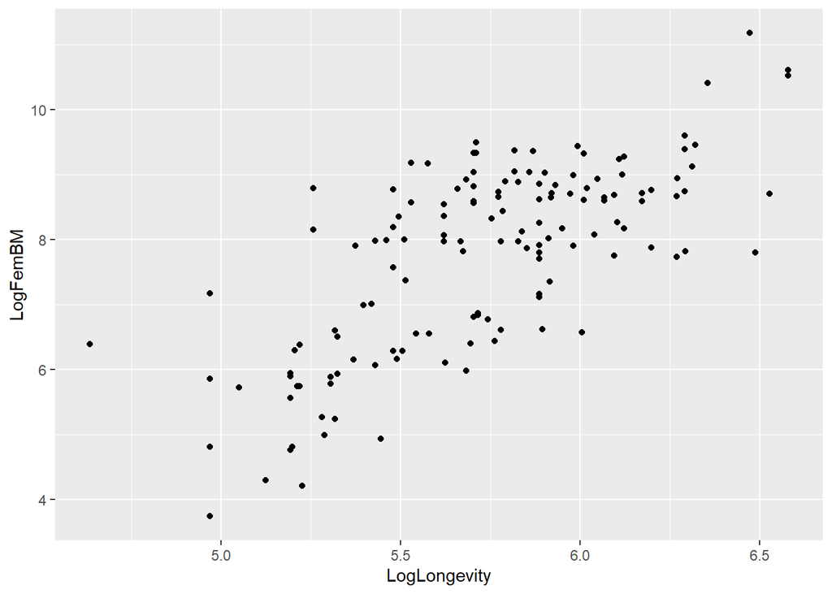

```r
print(p3)
```

```r
m1 <- lm(MaxLongevity_m ~ Body_mass_female_mean,data = d2)
m2 <- lm(MaxLongevity_m ~ LogFemBM,data = d2)
m3 <- lm(LogLongevity ~ LogFemBM,data = d2)

cat("The coefficients for:\n\n")
```

```
## The coefficients for:
```

```r
cat("Lifespan ~ Female body mass:           B_0 =",m1$coefficients[1],
    "   B1 =",m1$coefficients[2],"\n")
```

```
## Lifespan ~ Female body mass:           B_0 = 283.4721    B1 = 0.009049882
```

```r
cat("Lifespan ~ log(Female body mass):      B_0 =",m2$coefficients[1],
    "  B1 =",m2$coefficients[2],"\n")
```

```
## Lifespan ~ log(Female body mass):      B_0 = -128.8562   B1 = 59.34015
```

```r
cat("log(Lifespan) ~ log(Female body mass): B_0 =",m3$coefficients[1],
    "   B1 =",m3$coefficients[2],"\n")
```

```
## log(Lifespan) ~ log(Female body mass): B_0 = 4.258968    B1 = 0.1899547
```

Generate residuals for all three linear models, plot in relation to corresponding explanatory variable, and make histogram of residuals

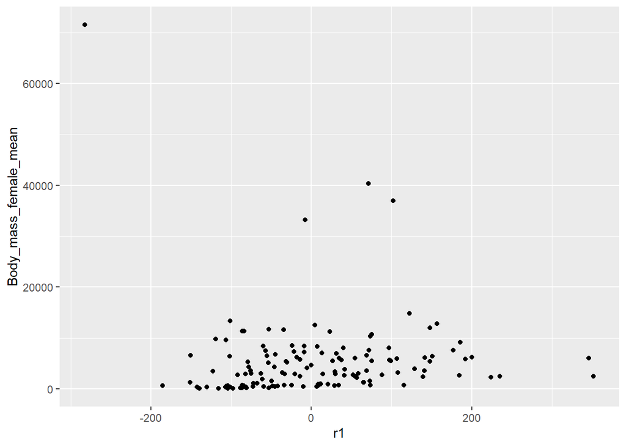

```r
d2 <- mutate(d2,r1 = m1$residuals,r2 = m2$residuals,r3 = m3$residuals)
rp1 <- ggplot(d2,aes(r1,Body_mass_female_mean)) + geom_point()
rp2 <- ggplot(d2,aes(r2,LogFemBM)) + geom_point()
rp3 <- ggplot(d2,aes(r3,LogFemBM)) + geom_point()
h1 <- ggplot(d2,aes(r1)) + geom_histogram(color = "black",fill = "skyblue",bins = 30)
h2 <- ggplot(d2,aes(r2)) + geom_histogram(color = "black",fill = "skyblue",bins = 30)
h3 <- ggplot(d2,aes(r3)) + geom_histogram(color = "black",fill = "skyblue",bins = 30)

print(rp1)
```

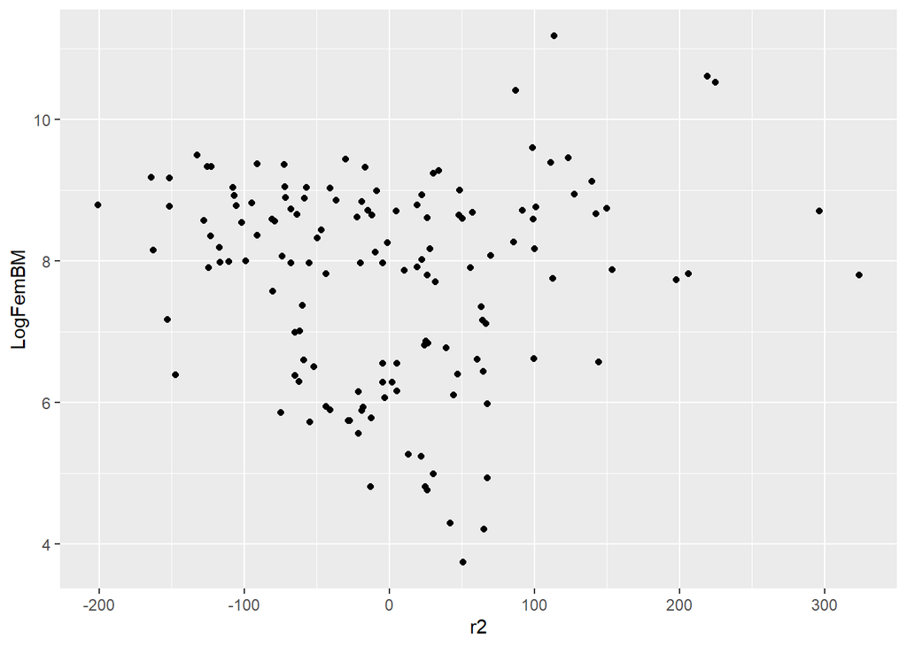

```r
print(rp2)
```

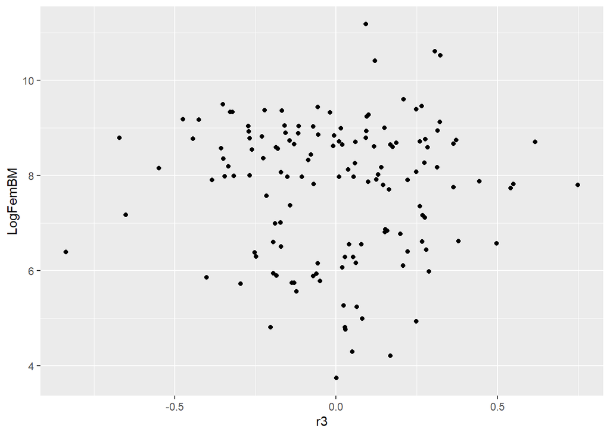

```r
print(rp3)
```

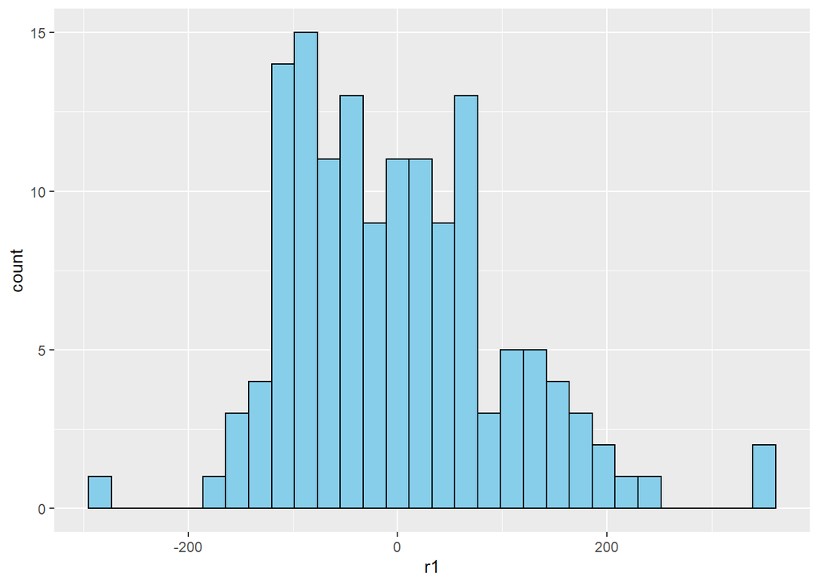

```r
print(h1)
```

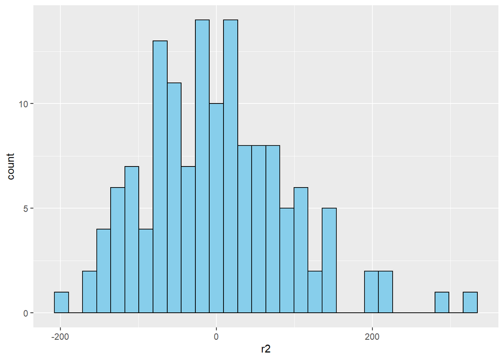

```r
print(h2)
```

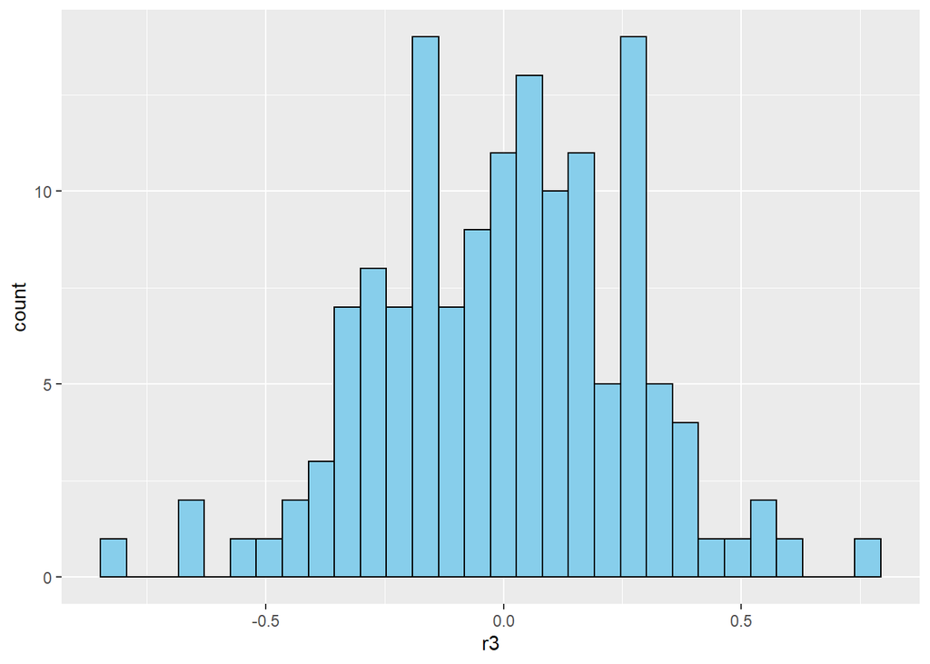

```r
print(h3)
```

Generate QQ plots for all three models. Do they appear normally distributed?

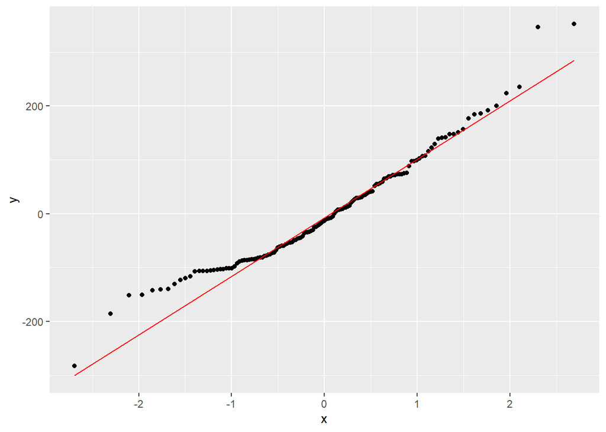

```r
qq1 <- ggplot(d2) + geom_qq(mapping = aes(sample = r1)) +
  geom_qq_line(mapping = aes(sample = r1),color = "red")
qq2 <- ggplot(d2) + geom_qq(mapping = aes(sample = r2)) +
  geom_qq_line(mapping = aes(sample = r2),color = "red")
qq3 <- ggplot(d2) + geom_qq(mapping = aes(sample = r3)) +
  geom_qq_line(mapping = aes(sample = r3),color = "red")

print(qq1)
```

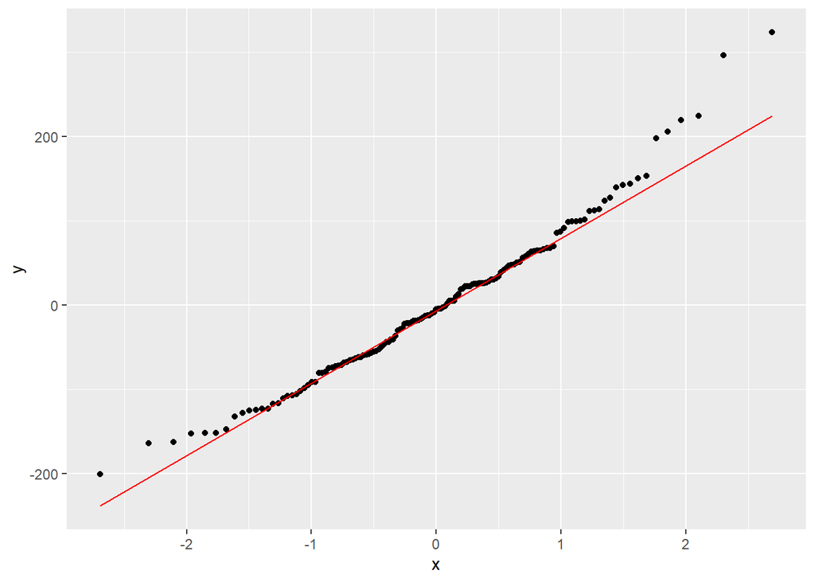

```r
print(qq2)
```

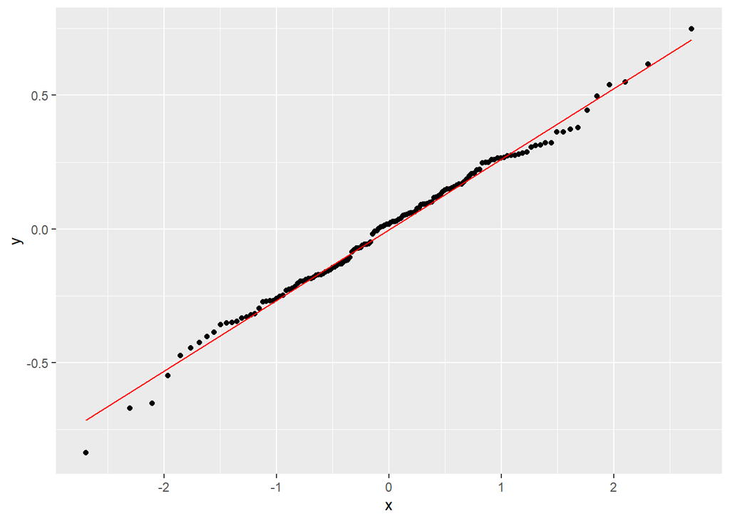

```r
print(qq3)
```

Based on these plots, it appears that the model where both variables are log- transformed is the closest fit to a normal distribution, and the model where neither variable is log-transformed is the least-close fit.

Run the plot() command for all three models. What do the plots suggest?

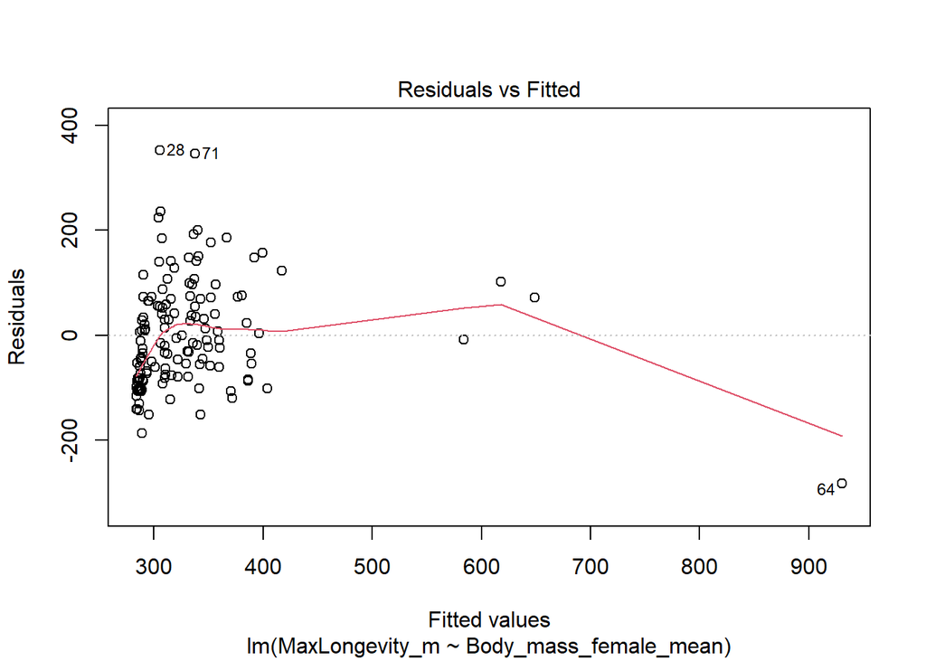

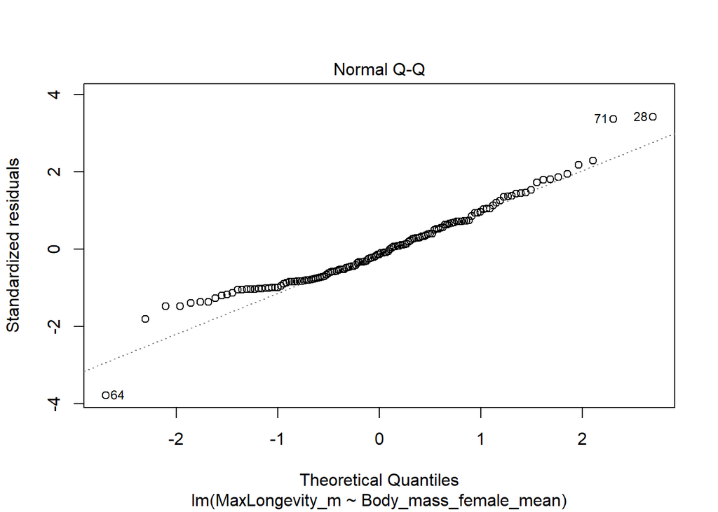

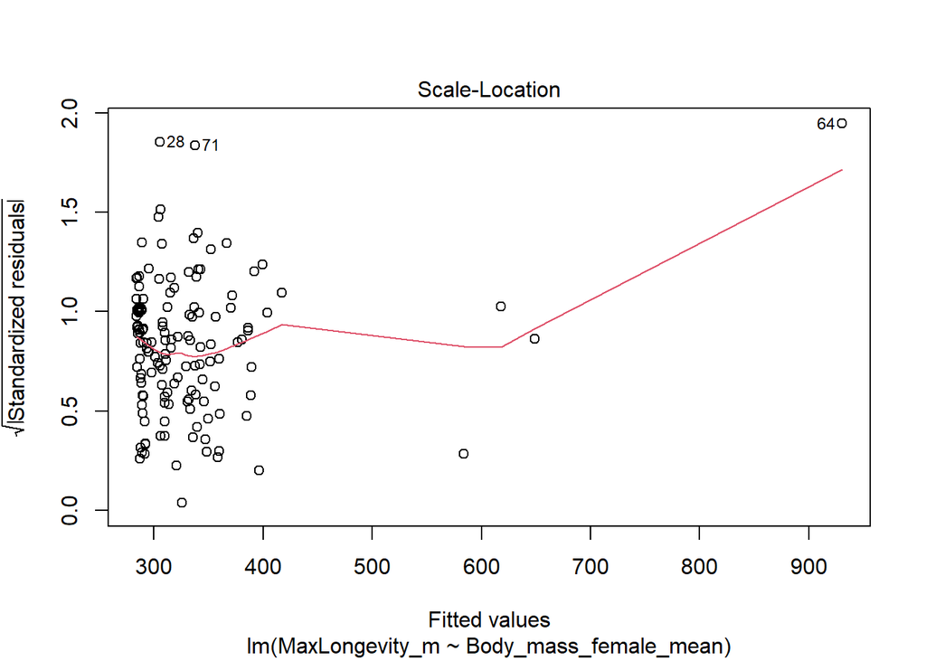

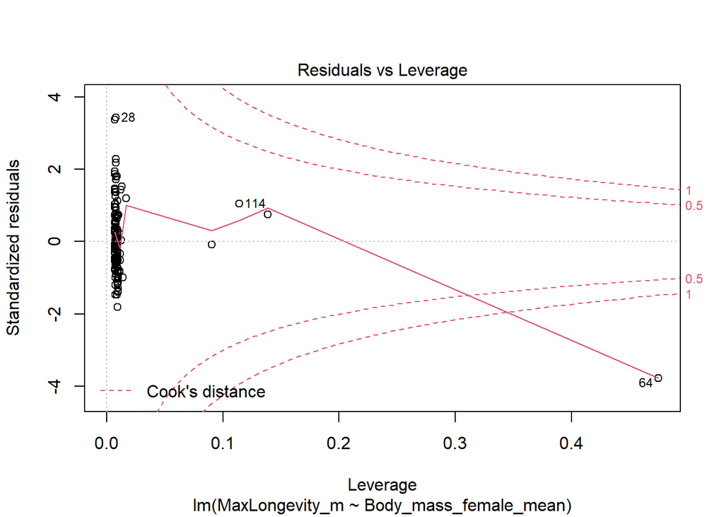

```r
plot(m1)
```

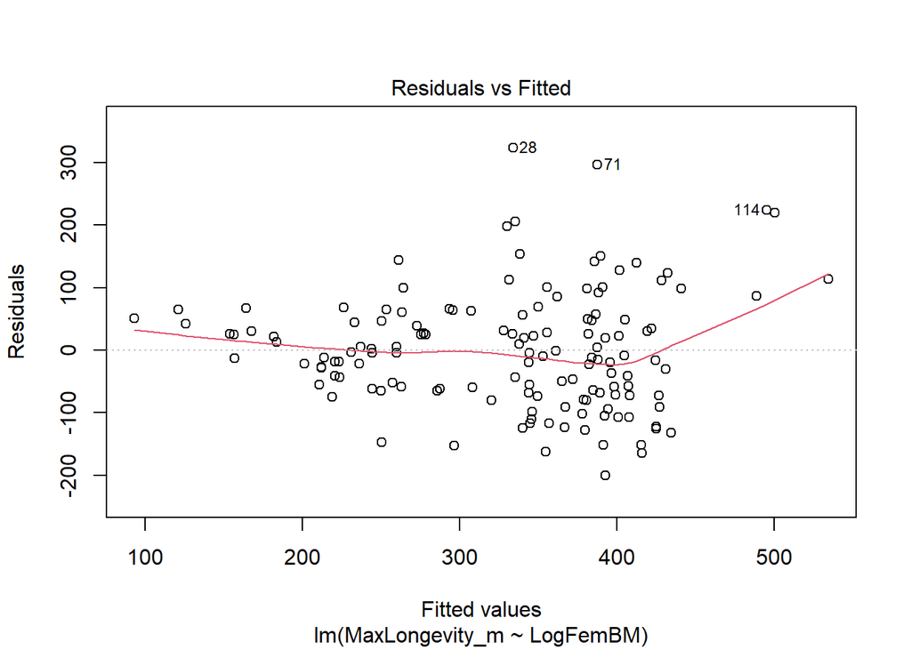

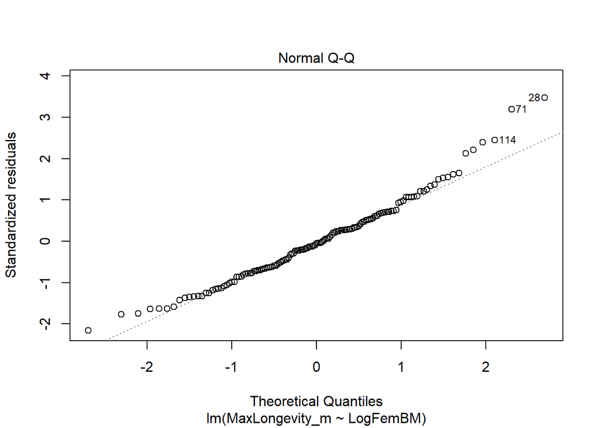

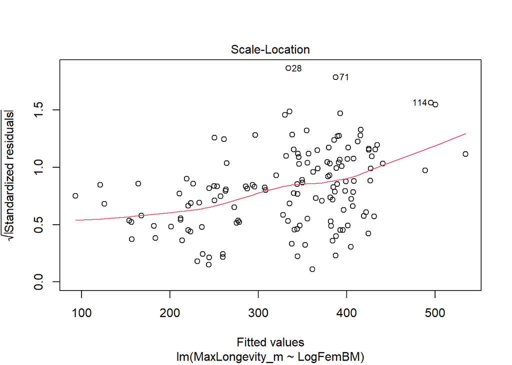

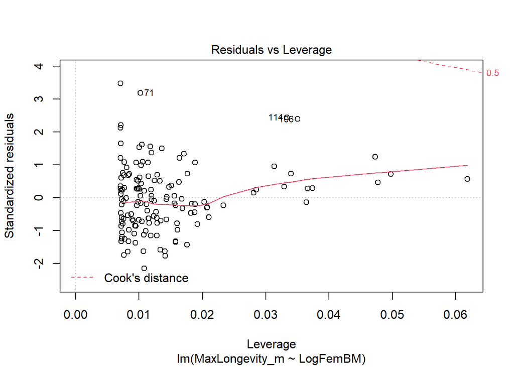

```r
plot(m2)
```

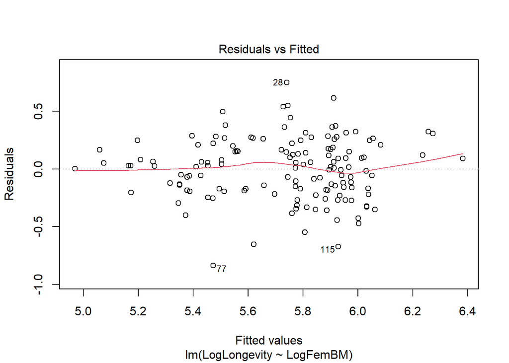

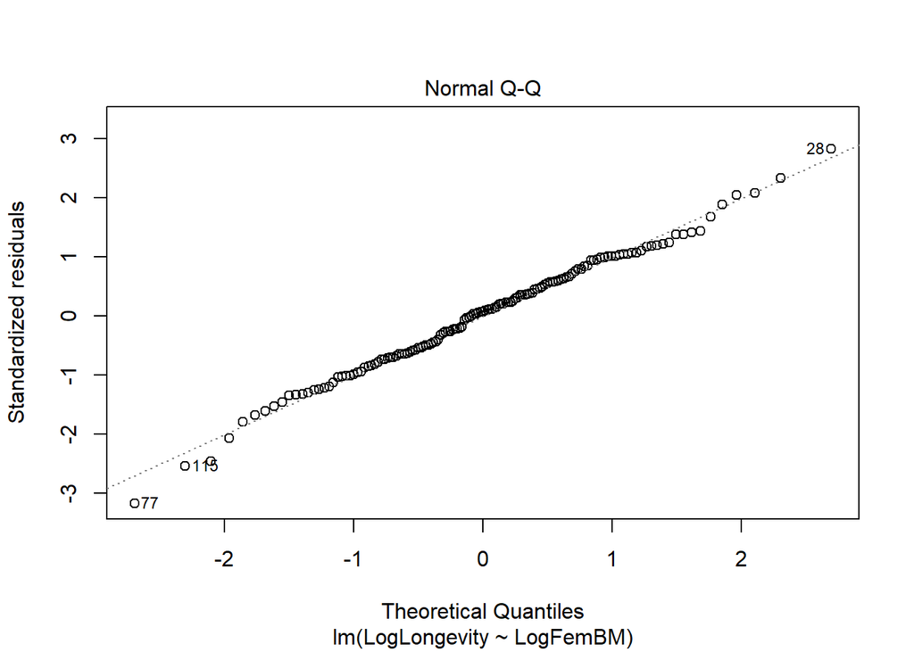

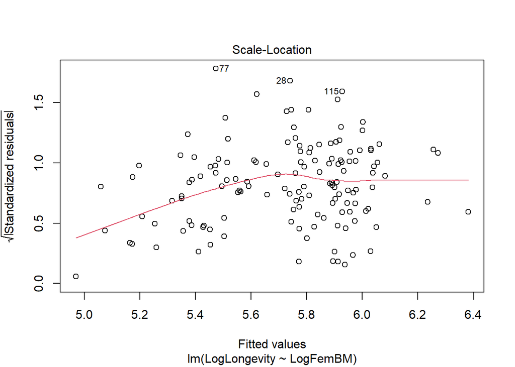

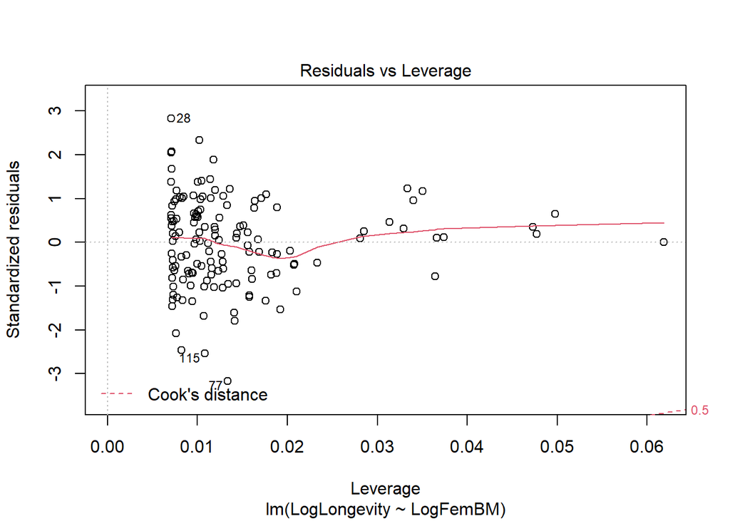

```r
plot(m3)
```

These plots, especially the Residuals vs. Leverage and Residuals vs. Fitted plots, show us if the residuals independent and don’t correlate with the explanatory variable. In this case, it seems like there is slight correlation in the residuals and the variables for the not-log transformed, and only body mass log-transformed cases, meaning that we can not just accept the core premise that the relationship between the variables is linear. However, for the plots where both variables are log-transformed, we see a straighter line for the residuals indicating greater independence, and thus lending greater support for using this linear model.

Run a Shapiro-Wilk Test on residuals for all 3 models. What do the results suggest?

```r
shapiro.test(d2$r1)
```

```
##
##  Shapiro-Wilk normality test
##
## data:  d2$r1
## W = 0.96352, p-value = 0.0008238
```

```r
shapiro.test(d2$r2)
```

```
##
##  Shapiro-Wilk normality test
##
## data:  d2$r2
## W = 0.97515, p-value = 0.01131
```

```r
shapiro.test(d2$r3)
```

```
##
##  Shapiro-Wilk normality test
##
## data:  d2$r3
## W = 0.99319, p-value = 0.7403
```

These results suggest that both model 1 (no log transformation) and model 2 (log tranformation of Female Body Mass only) have residuals which are not good fits to a normal distribution because the p-values were very low, meaning that we cannot accept the null hypothesis that the residuals are normal, and thus these models are not good models for linear regression. The model where both variables are log transformed is the best fit to a linear regression.